# filter_by_inverted_af_wecare_only

started: Alexey Larionov, 27Feb2017  
last updated: Alexey Larionov, 29Aug2017

# Summary

Perform burden-style aggregation of inverted genotypes  
SKAT-style genotypes inversion was done previously (for **total** AFs > 0.5)

- Calculate inv. AFs (MAFs)
- Remove variants with inv. AFs (MAFs) > 0.05
- Calculate some metrics
- Aggregate variants per gene
- Calculate some aggregated metrics (MAFs and MACs)

Result includes 8,649 genes ~2 rare protein-affecting variants per gene (mean)  
~5.4 inv-aggr-alt-counts (mean) per gene (median = 2, MACs)

Input data: 17,857 vars x 478 cases  
Output data: 16,809 vars x 478 cases

# start_section

```r
# Start time
Sys.time()
```

```
## [1] "2017-08-29 19:22:50 BST"
```

```r
# Clenan-up
rm(list=ls())

# Libraries location
.libPaths("/home/alarionov/R/my_libs_r3.4.1/")

# Base folder
library(knitr)
base_folder="/analysis/mtgroup_share/users/alexey/wecare_only_08.17"
opts_knit$set(root.dir = base_folder)
#setwd(base_folder)

# Libraries
library(dplyr)
```

```r
# Accessory function
source(paste(base_folder, "scripts", "f03_qqunif_plot.R", sep="/")) # for qq-plots
```

# load_data

```r
#base_folder="/analysis/mtgroup_share/users/alexey/wecare_only_08.17"
load(paste(base_folder, "results", "r07_filter_by_variant_effect_wecare_only.RData", sep="/"))
```

# check_data

```r
ls()
```

```
## [1] "base_folder"      "exac.df"          "genotypes_inv.mx"
## [4] "genotypes.mx"     "kgen.df"          "phenotypes.df"
## [7] "qqunif.plot"      "variants.df"
```

```r
dim(genotypes.mx)
```

```
## [1] 17857   478
```

```r
class(genotypes.mx)
```

```
## [1] "matrix"
```

```r
genotypes.mx[c(1:5,591),1:5] # 591 is inverted
```

```
##              P1_A01 P1_A02 P1_A03 P1_A04 P1_A05
## Var000000026      0     NA      0      0      0
## Var000000029      0      0      0      0      0
## Var000000031      0      0      0      0      0
## Var000000053      0      0      0      0     NA
## Var000000064      0      0      0      0     NA
## Var000011561      0      2     NA      2      2
```

```r
dim(genotypes_inv.mx)
```

```
## [1] 17857   478
```

```r
class(genotypes_inv.mx)
```

```
## [1] "matrix"
```

```r
genotypes_inv.mx[c(1:5,591),1:5] # 591 is inverted
```

```
##              P1_A01 P1_A02 P1_A03 P1_A04 P1_A05
## Var000000026      0     NA      0      0      0
## Var000000029      0      0      0      0      0
## Var000000031      0      0      0      0      0
## Var000000053      0      0      0      0     NA
## Var000000064      0      0      0      0     NA
## Var000011561      2      0     NA      0      0
```

```r
dim(kgen.df)
```

```
## [1] 17857     9
```

```r
colnames(kgen.df)
```

```
## [1] "SplitVarID"  "kgen.AC"     "kgen.AN"     "kgen.AF"     "kgen.AFR_AF"
## [6] "kgen.AMR_AF" "kgen.EAS_AF" "kgen.EUR_AF" "kgen.SAS_AF"
```

```r
kgen.df[1:5,1:5]
```

```
##                SplitVarID kgen.AC kgen.AN     kgen.AF kgen.AFR_AF
## Var000000026 Var000000026      NA      NA          NA          NA
## Var000000029 Var000000029       1    5008 0.000199681           0
## Var000000031 Var000000031       1    5008 0.000199681           0
## Var000000053 Var000000053      NA      NA          NA          NA
## Var000000064 Var000000064      NA      NA          NA          NA
```

```r
dim(exac.df)
```

```
## [1] 17857    48
```

```r
colnames(exac.df)
```

```
##  [1] "SplitVarID"              "exac_non_TCGA.AF"
##  [3] "exac_non_TCGA.AC"        "exac_non_TCGA.AN"
##  [5] "exac_non_TCGA.AC_FEMALE" "exac_non_TCGA.AN_FEMALE"
##  [7] "exac_non_TCGA.AC_MALE"   "exac_non_TCGA.AN_MALE"
##  [9] "exac_non_TCGA.AC_Adj"    "exac_non_TCGA.AN_Adj"
## [11] "exac_non_TCGA.AC_Hom"    "exac_non_TCGA.AC_Het"
## [13] "exac_non_TCGA.AC_Hemi"   "exac_non_TCGA.AC_AFR"
## [15] "exac_non_TCGA.AN_AFR"    "exac_non_TCGA.Hom_AFR"
## [17] "exac_non_TCGA.Het_AFR"   "exac_non_TCGA.Hemi_AFR"
## [19] "exac_non_TCGA.AC_AMR"    "exac_non_TCGA.AN_AMR"
## [21] "exac_non_TCGA.Hom_AMR"   "exac_non_TCGA.Het_AMR"
## [23] "exac_non_TCGA.Hemi_AMR"  "exac_non_TCGA.AC_EAS"
## [25] "exac_non_TCGA.AN_EAS"    "exac_non_TCGA.Hom_EAS"
## [27] "exac_non_TCGA.Het_EAS"   "exac_non_TCGA.Hemi_EAS"
## [29] "exac_non_TCGA.AC_FIN"    "exac_non_TCGA.AN_FIN"
## [31] "exac_non_TCGA.Hom_FIN"   "exac_non_TCGA.Het_FIN"
## [33] "exac_non_TCGA.Hemi_FIN"  "exac_non_TCGA.AC_NFE"
## [35] "exac_non_TCGA.AN_NFE"    "exac_non_TCGA.Hom_NFE"
## [37] "exac_non_TCGA.Het_NFE"   "exac_non_TCGA.Hemi_NFE"
## [39] "exac_non_TCGA.AC_SAS"    "exac_non_TCGA.AN_SAS"
## [41] "exac_non_TCGA.Hom_SAS"   "exac_non_TCGA.Het_SAS"
## [43] "exac_non_TCGA.Hemi_SAS"  "exac_non_TCGA.AC_OTH"
## [45] "exac_non_TCGA.AN_OTH"    "exac_non_TCGA.Hom_OTH"
## [47] "exac_non_TCGA.Het_OTH"   "exac_non_TCGA.Hemi_OTH"
```

```r
exac.df[1:5,1:5]
```

```
##                SplitVarID exac_non_TCGA.AF exac_non_TCGA.AC
## Var000000026 Var000000026               NA               NA
## Var000000029 Var000000029        1.506e-04               16
## Var000000031 Var000000031        2.354e-04               25
## Var000000053 Var000000053        1.883e-05                2
## Var000000064 Var000000064        9.416e-06                1
##              exac_non_TCGA.AN exac_non_TCGA.AC_FEMALE
## Var000000026               NA                      NA
## Var000000029           106210                       8
## Var000000031           106210                       4
## Var000000053           106210                       0
## Var000000064           106206                       0
```

```r
dim(variants.df)
```

```
## [1] 17857    45
```

```r
str(variants.df)
```

```
## 'data.frame':    17857 obs. of  45 variables:
##  $ SplitVarID        : Factor w/ 343824 levels "Var000000001",..: 26 29 31 53 64 227 237 300 413 430 ...
##  $ SYMBOL            : Factor w/ 19862 levels "A1BG","A1CF",..: 11149 11149 11149 8665 8665 540 540 18233 3808 6597 ...
##  $ TYPE              : Factor w/ 2 levels "INDEL","SNP": 2 2 2 2 2 2 2 2 2 2 ...
##  $ CHROM             : Factor w/ 25 levels "1","10","11",..: 1 1 1 1 1 1 1 1 1 1 ...
##  $ POS               : int  881871 883883 883946 897287 897792 987173 989899 1132513 1249141 1262635 ...
##  $ REF               : Factor w/ 2142 levels "A","AAAAAAAAAAAAAAAAAAAAAAAG",..: 1044 1575 539 539 539 1575 539 539 1044 1575 ...
##  $ ALT               : Factor w/ 1297 levels "A","AAAAAAAAAAAAACT",..: 1 323 989 989 989 664 989 989 1 1 ...
##  $ ac_raw            : int  1 2 1 1 1 1 1 2 1 1 ...
##  $ af_raw            : num  0.000711 0.001555 0.000774 0.000711 0.000722 ...
##  $ an_raw            : int  1406 1286 1292 1406 1386 1420 1414 1320 1378 1380 ...
##  $ Consequence       : Factor w/ 78 levels "3_prime_UTR_variant",..: 66 28 28 28 66 28 28 28 28 28 ...
##  $ SIFT_call         : Factor w/ 4 levels "deleterious",..: NA 1 1 1 NA 1 1 1 1 1 ...
##  $ SIFT_score        : num  NA 0 0.01 0.04 NA 0 0.02 0.02 0 0 ...
##  $ PolyPhen_call     : Factor w/ 4 levels "benign","possibly_damaging",..: NA 3 3 3 NA 3 3 3 3 3 ...
```

[output cut: 31 more lines]

```r
variants.df[1:5,1:5]
```

```
##                SplitVarID SYMBOL TYPE CHROM    POS
## Var000000026 Var000000026  NOC2L  SNP     1 881871
## Var000000029 Var000000029  NOC2L  SNP     1 883883
## Var000000031 Var000000031  NOC2L  SNP     1 883946
## Var000000053 Var000000053 KLHL17  SNP     1 897287
## Var000000064 Var000000064 KLHL17  SNP     1 897792
```

```r
dim(phenotypes.df)
```

```
## [1] 478  36
```

```r
str(phenotypes.df)
```

```
## 'data.frame':    478 obs. of  36 variables:
##  $ wes_id        : chr  "P1_A01" "P1_A02" "P1_A03" "P1_A04" ...
##  $ gwas_id       : chr  "id203568" "id357807" "id325472" "id304354" ...
##  $ merged_id     : chr  "P1_A01_id203568" "P1_A02_id357807" "P1_A03_id325472" "P1_A04_id304354" ...
##  $ filter        : chr  "pass" "pass" "pass" "pass" ...
##  $ cc            : int  1 1 1 1 1 1 0 1 1 0 ...
##  $ setno         : int  203568 357807 325472 304354 222648 244843 276284 297810 250898 226974 ...
##  $ registry      : Factor w/ 5 levels "de","IA","IR",..: 3 4 2 2 5 4 2 4 4 2 ...
##  $ family_history: int  1 0 1 1 1 1 1 1 1 0 ...
##  $ age_dx        : int  49 35 32 33 44 28 28 38 35 36 ...
##  $ age_ref       : num  58 36 41 34 49 28 32 44 35 38 ...
##  $ rstime        : num  10.17 1.83 9.75 1.59 5.66 ...
##  $ eig1_gwas     : num  -0.00389 -0.00379 -0.01011 -0.01288 -0.01086 ...
##  $ eig2_gwas     : num  0.00266 0.00246 -0.0001 0.00595 0.01157 ...
##  $ eig3_gwas     : num  0.06803 0.05055 -0.00603 0.00747 0.00144 ...
```

[output cut: 22 more lines]

```r
phenotypes.df[1:5,1:5]
```

```
##        wes_id  gwas_id       merged_id filter cc
## P1_A01 P1_A01 id203568 P1_A01_id203568   pass  1
## P1_A02 P1_A02 id357807 P1_A02_id357807   pass  1
## P1_A03 P1_A03 id325472 P1_A03_id325472   pass  1
## P1_A04 P1_A04 id304354 P1_A04_id304354   pass  1
## P1_A05 P1_A05 id222648 P1_A05_id222648   pass  1
```

```r
# Check consistency of rownames and colnames
sum(colnames(genotypes.mx) != rownames(phenotypes.df))
```

```
## [1] 0
```

```r
sum(rownames(genotypes.mx) != rownames(kgen.df))
```

```
## [1] 0
```

```r
sum(rownames(genotypes.mx) != rownames(exac.df))
```

```
## [1] 0
```

```r
sum(rownames(genotypes.mx) != rownames(variants.df))
```

```
## [1] 0
```

# calculate_inv_AFs

Invert genotypes and recalculate AFs if **total** AFs > 0.5  
**Total** AFs are used instead of **control’s** AFs for consistency with  
“flipping” genotypes in SKAT

Calculate inverted an, ac, af in all samples and in sub-groups

```r
# Prepare table for output
variants_inv.df <- cbind(variants.df,
                     inverted=rep(FALSE,nrow(variants.df)),
                     ac_inv=variants.df$ac_all,
                     an_inv=variants.df$an_all,
                     af_inv=variants.df$af_all,
                     ac_cbc_inv=variants.df$ac_cbc,
                     an_cbc_inv=variants.df$an_cbc,
                     af_cbc_inv=variants.df$af_cbc,
                     ac_ubc_inv=variants.df$ac_ubc,
                     an_ubc_inv=variants.df$an_ubc,
                     af_ubc_inv=variants.df$af_ubc,
                     ac_cbc_fam_inv=variants.df$ac_cbc_fam,
                     an_cbc_fam_inv=variants.df$an_cbc_fam,
                     af_cbc_fam_inv=variants.df$af_cbc_fam,
                     ac_cbc_nofam_inv=variants.df$ac_cbc_nofam,
                     an_cbc_nofam_inv=variants.df$an_cbc_nofam,
                     af_cbc_nofam_inv=variants.df$af_cbc_nofam,
                     ac_ubc_fam_inv=variants.df$ac_ubc_fam,
                     an_ubc_fam_inv=variants.df$an_ubc_fam,
                     af_ubc_fam_inv=variants.df$af_ubc_fam,
                     ac_ubc_nofam_inv=variants.df$ac_ubc_nofam,
                     an_ubc_nofam_inv=variants.df$an_ubc_nofam,
                     af_ubc_nofam_inv=variants.df$af_ubc_nofam)

# Select subgroups of samples
cbc_cases <- phenotypes.df$cc == 1
sum(cbc_cases)
```

```
## [1] 233
```

```r
ubc_cases <- phenotypes.df$cc == 0
sum(ubc_cases)
```

```
## [1] 245
```

```r
cbc_fam_cases <- phenotypes.df$cc == 1 & phenotypes.df$family_history == 1
sum(cbc_fam_cases)
```

```
## [1] 83
```

```r
cbc_nofam_cases <- phenotypes.df$cc == 1 & phenotypes.df$family_history == 0
sum(cbc_nofam_cases)
```

```
## [1] 150
```

```r
ubc_fam_cases <- phenotypes.df$cc == 0 & phenotypes.df$family_history == 1
sum(ubc_fam_cases)
```

```
## [1] 71
```

```r
ubc_nofam_cases <- phenotypes.df$cc == 0 & phenotypes.df$family_history == 0
sum(ubc_nofam_cases)
```

```
## [1] 174
```

```r
# For each variant
for(var in 1:nrow(variants_inv.df)){

  # if total AF > 0.5
  if(variants_inv.df[var,"af_all"] > 0.5){

    # Flag variant
    TRUE -> variants_inv.df[var, "inverted"]

    # Get inverted genotypes
    genotypes_inv <- genotypes_inv.mx[var,]

    # Calculate total inverted AFs
    ac_inv <- sum(genotypes_inv, na.rm=TRUE)
    an_inv <- 2*sum(!is.na(genotypes_inv))
    af_inv <- ac_inv/an_inv

    # Calculate inverted cbc AFs
    ac_cbc_inv <- sum(genotypes_inv[cbc_cases], na.rm=TRUE)
    an_cbc_inv <- 2*sum(!is.na(genotypes_inv[cbc_cases]))
    af_cbc_inv <- ac_cbc_inv/an_cbc_inv

    # Calculate inverted ubc AFs
    ac_ubc_inv <- sum(genotypes_inv[ubc_cases], na.rm=TRUE)
    an_ubc_inv <- 2*sum(!is.na(genotypes_inv[ubc_cases]))
    af_ubc_inv <- ac_ubc_inv/an_ubc_inv

    # Calculate inverted cbc_fam AFs
    ac_cbc_fam_inv <- sum(genotypes_inv[cbc_fam_cases], na.rm=TRUE)
    an_cbc_fam_inv <- 2*sum(!is.na(genotypes_inv[cbc_fam_cases]))
    af_cbc_fam_inv <- ac_cbc_fam_inv/an_cbc_fam_inv

    # Calculate inverted cbc_nofam AFs
    ac_cbc_nofam_inv <- sum(genotypes_inv[cbc_nofam_cases], na.rm=TRUE)
    an_cbc_nofam_inv <- 2*sum(!is.na(genotypes_inv[cbc_nofam_cases]))
    af_cbc_nofam_inv <- ac_cbc_nofam_inv/an_cbc_nofam_inv

    # Calculate inverted ubc_fam AFs
    ac_ubc_fam_inv <- sum(genotypes_inv[ubc_fam_cases], na.rm=TRUE)
    an_ubc_fam_inv <- 2*sum(!is.na(genotypes_inv[ubc_fam_cases]))
    af_ubc_fam_inv <- ac_ubc_fam_inv/an_ubc_fam_inv

    # Calculate inverted ubc_nofam AFs
    ac_ubc_nofam_inv <- sum(genotypes_inv[ubc_nofam_cases], na.rm=TRUE)
    an_ubc_nofam_inv <- 2*sum(!is.na(genotypes_inv[ubc_nofam_cases]))
    af_ubc_nofam_inv <- ac_ubc_nofam_inv/an_ubc_nofam_inv

    # Add inverted AFs to the variants data.frame
    variants_inv.df[var, c("ac_inv", "an_inv", "af_inv",
                           "ac_cbc_inv", "an_cbc_inv", "af_cbc_inv",
                           "ac_ubc_inv", "an_ubc_inv", "af_ubc_inv",
                           "ac_cbc_fam_inv", "an_cbc_fam_inv", "af_cbc_fam_inv",
                           "ac_cbc_nofam_inv", "an_cbc_nofam_inv", "af_cbc_nofam_inv",
                           "ac_ubc_fam_inv", "an_ubc_fam_inv", "af_ubc_fam_inv",
                           "ac_ubc_nofam_inv", "an_ubc_nofam_inv", "af_ubc_nofam_inv")] <-
      c(ac_inv, an_inv, af_inv,
        ac_cbc_inv, an_cbc_inv, af_cbc_inv,
        ac_ubc_inv, an_ubc_inv, af_ubc_inv,
        ac_cbc_fam_inv, an_cbc_fam_inv, af_cbc_fam_inv,
        ac_cbc_nofam_inv, an_cbc_nofam_inv, af_cbc_nofam_inv,
        ac_ubc_fam_inv, an_ubc_fam_inv, af_ubc_fam_inv,
        ac_ubc_nofam_inv, an_ubc_nofam_inv, af_ubc_nofam_inv)

    # Clean-up
    rm(genotypes_inv,
       ac_inv, an_inv, af_inv,
       ac_cbc_inv, an_cbc_inv, af_cbc_inv,
       ac_ubc_inv, an_ubc_inv, af_ubc_inv,
       ac_cbc_fam_inv, an_cbc_fam_inv, af_cbc_fam_inv,
       ac_cbc_nofam_inv, an_cbc_nofam_inv, af_cbc_nofam_inv,
       ac_ubc_fam_inv, an_ubc_fam_inv, af_ubc_fam_inv,
       ac_ubc_nofam_inv, an_ubc_nofam_inv, af_ubc_nofam_inv)

  }
}

# Number of invered variants
sum(variants_inv.df$inverted) # 150
```

```
## [1] 150
```

```r
# Some effects of the inversion
max(variants_inv.df$af_all) # ~0.99
```

```
## [1] 0.9989011
```

```r
max(variants_inv.df$af_inv) # 0.5
```

```
## [1] 0.5
```

```r
# clean-up
rm(var, cbc_cases, ubc_cases, cbc_fam_cases, cbc_nofam_cases, ubc_fam_cases, ubc_nofam_cases)
```

# remove_common_variants

Remove 1,048 variants with total inv. AFs (MAFs) > 0.05  
16,809

```r
# Make list of common variants
common_variants <- variants_inv.df$af_all > 0.05
sum(common_variants) # 1,048
```

```
## [1] 1048
```

```r
# Apply filter
genotypes.mx <- genotypes.mx[!common_variants,]
kgen.df <- kgen.df[!common_variants,]
exac.df <- exac.df[!common_variants,]
variants.df <- variants.df[!common_variants,]

genotypes_inv.mx <- genotypes_inv.mx[!common_variants,]
variants_inv.df <- variants_inv.df[!common_variants,]

# Explore resuilts
dim(genotypes.mx)
```

```
## [1] 16809   478
```

```r
max(variants.df$af_all) # ~0.05
```

```
## [1] 0.04988914
```

```r
max(variants_inv.df$af_inv) # ~0.05
```

```
## [1] 0.04988914
```

```r
# Clean-up
rm(common_variants)
```

# — explore selected variants —

## count_selected_multiallelic_varaints

```r
summary(variants.df$Multiallelic) # 370
```

```
##    Mode   FALSE    TRUE
## logical   16439     370
```

## explore_AFs_in_selected_variants

Most of selected variants are rare (median ~0.1%)  
The weihgting will further prioritise rare variants amongst the remaining ones.

```r
mean(variants.df$af_all) # ~0.3%
```

```
## [1] 0.003013616
```

```r
median(variants.df$af_all) # ~0.1%
```

```
## [1] 0.001070664
```

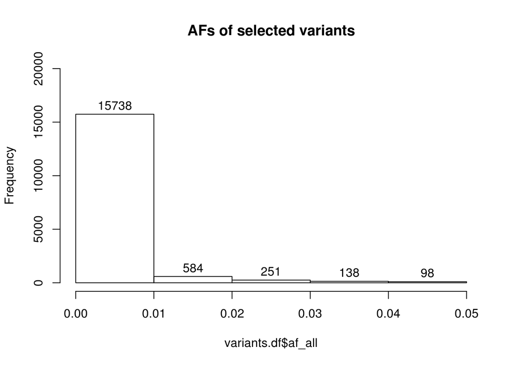

```r
hist(variants.df$af_all, main="AFs of selected variants", labels = TRUE, ylim=c(0,20000), breaks=5)
```

## explore_variants_counts_per_gene

```r
# Get number of genes
length(unique(variants.df$SYMBOL)) # 8,649
```

```
## [1] 8649
```

```r
# Look at the top genes with high counts of variants
x <- sort(table(as.vector(variants.df$SYMBOL)), decreasing = TRUE)
x[1:200]
```

```
##
##    DNAH7    DNAH3    ABCA4  PKHD1L1   COL6A6    DUOX2   MYO18B     CUBN
##       25       20       15       15       14       14       14       13
##   IGSF10   MT-CYB  PDE4DIP    TRPM1      ATM   DNAH14    LAMA1     LRBA
##       13       13       13       13       12       12       12       12
##   PKD1L2     POLG    C2CD3    ECT2L     NOD2   PIEZO1     PLB1     POLQ
##       12       12       11       11       11       11       11       11
##   PRUNE2     VWA8    ABCC2   CCDC66    CHEK2 FAM160A1   FER1L6      FN1
##       11       11       10       10       10       10       10       10
##    LRRC9    MYO7A    MYOM2     NID2    SPTA1     SPTB    ATP7B  COL28A1
##       10       10       10       10       10       10        9        9
##    CSMD3    DCHS2   DNAH12   GPR113    LAMA2    LAMB4      MPO     MUC4
##        9        9        9        9        9        9        9        9
##    MYH13     MYH4    PKHD1   SLC5A4       TG      TNC   ZNF106   ZNF568
##        9        9        9        9        9        9        9        9
##    ABCB5      ACE ADAMTSL1    AMPD1     ANK1     ASPM       C9  CCDC141
##        8        8        8        8        8        8        8        8
##    CD109   CELSR2    CES5A   DNASE1    DNHD1      EPX KIAA1217    KRT36
##        8        8        8        8        8        8        8        8
##    LAMB2    LRRK1    MKI67    MYH14    MYO1A    MYO7B     MYOF    NLRP5
##        8        8        8        8        8        8        8        8
##     PCK2    POMT1   PTPN13    PTPRQ     SETX       SI    STAB2     TPTE
##        8        8        8        8        8        8        8        8
##     UTRN      XDH   ZNF268    A2ML1    ABCA8   ABCC11 ADAMTS14    AGBL1
##        8        8        8        7        7        7        7        7
##    ALPK2     ANO2     ATIC      BLK   CAPN13  CCDC136     CCR5     CFTR
##        7        7        7        7        7        7        7        7
##    CNTLN     COBL  COL15A1      CR2  CTTNBP2    DAAM2     DPYD   EGFLAM
##        7        7        7        7        7        7        7        7
##     ELP2    EPB41     EXO1    FHAD1   FRMPD1   IQGAP2 KIAA0556    KRT75
##        7        7        7        7        7        7        7        7
##    LAMC3      LPA    LRRK2  MICALCL     MPDZ    MYH15     NAV2    NRDE2
##        7        7        7        7        7        7        7        7
##     OCA2    OGDHL    PADI4      PAH   PDCD11     PHKB   PLA2R1    PTPRB
##        7        7        7        7        7        7        7        7
##  SLC10A2    SSFA2  TBC1D17     TEP1    TEX15     TLN2     TMC8  TMPRSS7
##        7        7        7        7        7        7        7        7
##  TRAPPC9    TTLL6  TUBGCP6    UGGT2     ULK4    USP45    UTP20    WDR27
##        7        7        7        7        7        7        7        7
##     WDR3    WDR41   ZNF226   ZNF528      A2M    ABCA3   ABCC12   ACAD10
##        7        7        7        7        6        6        6        6
##    ACOXL   AKAP11  ALDH1B1     ALLC    ALPK1  ARHGAP8   ATP10B  ATP13A5
##        6        6        6        6        6        6        6        6
##   ATP2C2   ATP8B4 C10ORF68  C5orf42       C7   CABIN1    CAPN9   CELSR1
##        6        6        6        6        6        6        6        6
##   CEP112   CEP164   CEP192    CFHR5     CILP   CLTCL1   CYP1A1  CYP24A1
##        6        6        6        6        6        6        6        6
##    DNAH6    DOCK5    DOCK6   DOPEY2     DYSF   EFCAB6    ERCC6       F5
##        6        6        6        6        6        6        6        6
##  FAM179A  FAM221A     FGGY     GBE1   GEMIN5     GLDN    GLIS3   HHIPL2
##        6        6        6        6        6        6        6        6
```

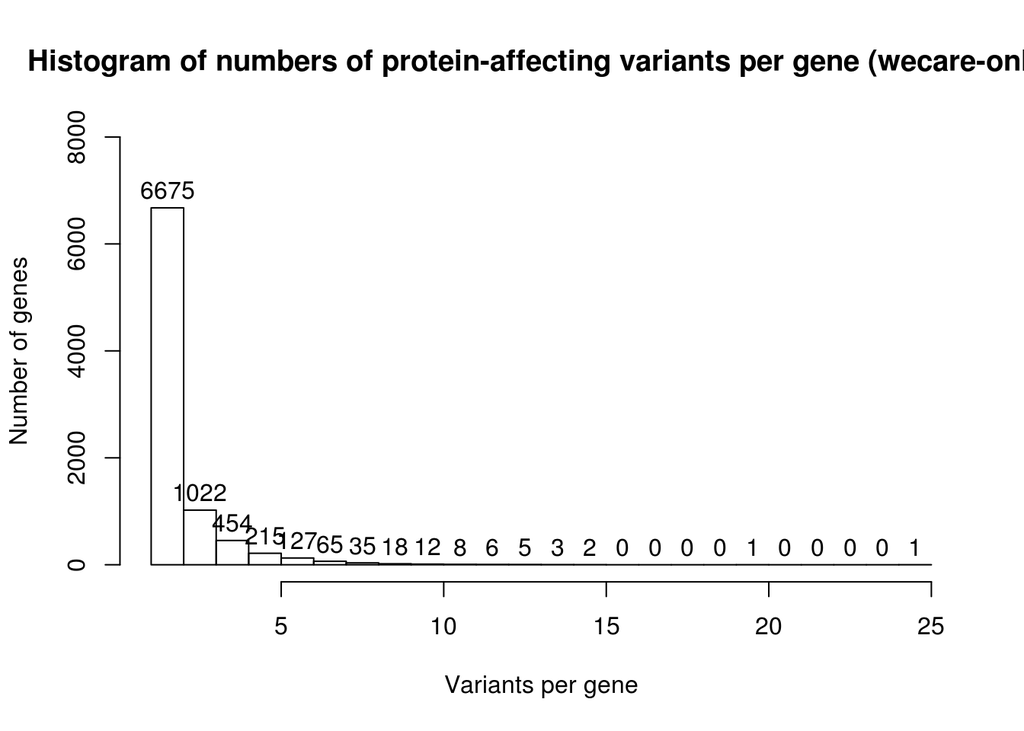

```r
# Table for histogram of numbers of protein-affecting variants per gene
# (not sure whether group_by preserves the order of genes etc,
# but this is not important here)
y <- variants.df %>% group_by(SYMBOL) %>% summarise(n())
"vars_count" -> colnames(y)[2]

# Plot the histogram
hist(y$vars_count, main="Histogram of numbers of protein-affecting variants per gene (wecare-only)", xlab="Variants per gene", ylab="Number of genes", ylim=c(0,8000), breaks=25, labels = TRUE)
```

```r
# Mean number of variants per gene
mean(y$vars_count) # ~2.0
```

```
## [1] 1.943462
```

```r
# Clean-up
rm(x,y)
```

# aggregate_per_gene

```r
# Get list of genes
genes <- unique(as.character(as.vector(variants.df$SYMBOL)))
length(genes)
```

```
## [1] 8649
```

```r
# Make empty matrix for the inverted gene-aggregated data
genes_inv_aggr_data.mx <- matrix(ncol=ncol(genotypes.mx),nrow=0)
colnames(genes_inv_aggr_data.mx) <- colnames(genotypes.mx)

# Calculate inverted gene-aggregated variants' counts
for(gene in genes){

  # Get the gene's variants
  vars <- variants.df$SYMBOL == gene

  # Get the number of variants
  num_vars <- sum(vars)

  # For single-variant genes
  if(num_vars==1){

    # Nothing to aggregate
    counts <- genotypes_inv.mx[vars,] # vector, preserves NA
    0 -> counts[is.na(counts)] # equivalent to na.rm=TRUE below

  # For genes with multiple varians
  }else{

    # Sum alleles in the variants
    counts <- apply(genotypes_inv.mx[vars,], 2, sum, na.rm=TRUE)

  }

  # Add result to output table
  genes_inv_aggr_data.mx <- rbind(genes_inv_aggr_data.mx, counts)

  # Clean-up
  rm(vars, num_vars, counts)

}

# Check result
# (atrix with aggregated inverted counts per gene per case)
dim(genes_inv_aggr_data.mx)
```

```
## [1] 8649  478
```

```r
genes -> rownames(genes_inv_aggr_data.mx)
genes_inv_aggr_data.mx[1:5,1:5]
```

```
##        P1_A01 P1_A02 P1_A03 P1_A04 P1_A05
## NOC2L       0      0      0      0      0
## KLHL17      0      0      0      0      0
## AGRN        0      0      0      0      0
## TTLL10      0      0      0      0      0
## CPSF3L      0      0      0      0      0
```

```r
# Clean-up
rm(gene, genes)
```

# make_inv_aggr_summary_per_gene

```r
# Get list of genes
# (check that there is no NAs; get rid of NAs if they are present!)
genes <- unique(as.character(variants_inv.df$SYMBOL))
length(genes)
```

```
## [1] 8649
```

```r
sum(is.na(genes))
```

```
## [1] 0
```

```r
# Prepare blank matrix for output
header <- c("gene", "num_var", "inverted", "multiallelic",
            "aggr_ac", "aggr_an", "aggr_af",
            "aggr_ac_cbc", "aggr_an_cbc", "aggr_af_cbc",
            "aggr_ac_ubc", "aggr_an_ubc", "aggr_af_ubc",
            "aggr_ac_cbc_fam", "aggr_an_cbc_fam", "aggr_af_cbc_fam",
            "aggr_ac_cbc_nofam", "aggr_an_cbc_nofam", "aggr_af_cbc_nofam",
            "aggr_ac_ubc_fam", "aggr_an_ubc_fam", "aggr_af_ubc_fam",
            "aggr_ac_ubc_nofam", "aggr_an_ubc_nofam", "aggr_af_ubc_nofam",
            "cbc_ubc_call", "cbc_ubc_fisher_p")

genes_inv_aggr_info.mx <- matrix(nrow=0, ncol=length(header))
header -> colnames(genes_inv_aggr_info.mx)

# Get lists of samples in subgroups
cbc_cases <- phenotypes.df$cc == 1
sum(cbc_cases)
```

```
## [1] 233
```

```r
ubc_cases <- phenotypes.df$cc == 0
sum(ubc_cases)
```

```
## [1] 245
```

```r
cbc_fam_cases <- phenotypes.df$cc == 1 & phenotypes.df$family_history == 1
sum(cbc_fam_cases)
```

```
## [1] 83
```

```r
cbc_nofam_cases <- phenotypes.df$cc == 1 & phenotypes.df$family_history == 0
sum(cbc_nofam_cases)
```

```
## [1] 150
```

```r
ubc_fam_cases <- phenotypes.df$cc == 0 & phenotypes.df$family_history == 1
sum(ubc_fam_cases)
```

```
## [1] 71
```

```r
ubc_nofam_cases <- phenotypes.df$cc == 0 & phenotypes.df$family_history == 0
sum(ubc_nofam_cases)
```

```
## [1] 174
```

```r
# For each gene
for(gene in genes){

  # Get list of variants
  vars <- variants_inv.df$SYMBOL == gene

  # Count variants
  num_var <- sum(vars)

  # Check if any variant is inverted
  inverted <- FALSE
  if(any(variants_inv.df[vars, "inverted"])) inverted <- TRUE

  # Check if any variant is multiallelic
  multiallelic <- FALSE
  if(any(variants_inv.df[vars, "Multiallelic"])) multiallelic <- TRUE

  # Get genotypes matrices for subgroups
  gt <- genes_inv_aggr_data.mx[gene,]

  gt_cbc <- gt[cbc_cases]
  gt_ubc <- gt[ubc_cases]

  gt_cbc_fam <- gt[cbc_fam_cases]
  gt_cbc_nofam <- gt[cbc_nofam_cases]

  gt_ubc_fam <- gt[ubc_fam_cases]
  gt_ubc_nofam <- gt[ubc_nofam_cases]

  # Calculate aggregated metrics in sub-groups
  aggr_ac <- sum(gt, na.rm=TRUE)
  aggr_an <- 2*sum(!is.na(gt))
  aggr_af <- aggr_ac / aggr_an

  aggr_ac_cbc <- sum(gt_cbc, na.rm=TRUE)
  aggr_an_cbc <- 2*sum(!is.na(gt_cbc))
  aggr_af_cbc <- aggr_ac_cbc / aggr_an_cbc

  aggr_ac_ubc <- sum(gt_ubc, na.rm=TRUE)
  aggr_an_ubc <- 2*sum(!is.na(gt_ubc))
  aggr_af_ubc <- aggr_ac_ubc / aggr_an_ubc

  aggr_ac_cbc_fam <- sum(gt_cbc_fam, na.rm=TRUE)
  aggr_an_cbc_fam <- 2*sum(!is.na(gt_cbc_fam))
  aggr_af_cbc_fam <- aggr_ac_cbc_fam / aggr_an_cbc_fam

  aggr_ac_cbc_nofam <- sum(gt_cbc_nofam, na.rm=TRUE)
  aggr_an_cbc_nofam <- 2*sum(!is.na(gt_cbc_nofam))
  aggr_af_cbc_nofam <- aggr_ac_cbc_nofam / aggr_an_cbc_nofam

  aggr_ac_ubc_fam <- sum(gt_ubc_fam, na.rm=TRUE)
  aggr_an_ubc_fam <- 2*sum(!is.na(gt_ubc_fam))
  aggr_af_ubc_fam <- aggr_ac_ubc_fam / aggr_an_ubc_fam

  aggr_ac_ubc_nofam <- sum(gt_ubc_nofam, na.rm=TRUE)
  aggr_an_ubc_nofam <- 2*sum(!is.na(gt_ubc_nofam))
  aggr_af_ubc_nofam <- aggr_ac_ubc_nofam / aggr_an_ubc_nofam

  # Call for cbc vs ubc
  if(aggr_af_cbc == aggr_af_ubc) cbc_ubc_call <- "uncertain"
  if(aggr_af_cbc > aggr_af_ubc) cbc_ubc_call <- "risk"
  if(aggr_af_cbc < aggr_af_ubc) cbc_ubc_call <- "protective"

  # Fisher exact test: cbc vs ubc
  test.mx <- matrix(c(aggr_ac_cbc, aggr_an_cbc - aggr_ac_cbc, aggr_ac_ubc, aggr_an_ubc - aggr_ac_ubc), nrow=2)
  cbc_ubc_fisher_p <- fisher.test(test.mx)$p.value

  # Record to result matrix
  genes_inv_aggr_info.mx <- rbind(genes_inv_aggr_info.mx, c(gene, num_var, inverted, multiallelic,
                              aggr_ac, aggr_an, aggr_af,
                              aggr_ac_cbc, aggr_an_cbc, aggr_af_cbc,
                              aggr_ac_ubc, aggr_an_ubc, aggr_af_ubc,
                              aggr_ac_cbc_fam, aggr_an_cbc_fam, aggr_af_cbc_fam,
                              aggr_ac_cbc_nofam, aggr_an_cbc_nofam, aggr_af_cbc_nofam,
                              aggr_ac_ubc_fam, aggr_an_ubc_fam, aggr_af_ubc_fam,
                              aggr_ac_ubc_nofam, aggr_an_ubc_nofam, aggr_af_ubc_nofam,
                              cbc_ubc_call, cbc_ubc_fisher_p))

  # Clean-up
  rm(vars, num_var, inverted, multiallelic,
     gt, gt_cbc, gt_ubc,
     gt_cbc_fam, gt_cbc_nofam,
     gt_ubc_fam, gt_ubc_nofam,
     aggr_ac, aggr_an, aggr_af,
     aggr_ac_cbc, aggr_an_cbc, aggr_af_cbc,
     aggr_ac_ubc, aggr_an_ubc, aggr_af_ubc,
     aggr_ac_cbc_fam, aggr_an_cbc_fam, aggr_af_cbc_fam,
     aggr_ac_cbc_nofam, aggr_an_cbc_nofam, aggr_af_cbc_nofam,
     aggr_ac_ubc_fam, aggr_an_ubc_fam, aggr_af_ubc_fam,
     aggr_ac_ubc_nofam, aggr_an_ubc_nofam, aggr_af_ubc_nofam,
     test.mx, cbc_ubc_call, cbc_ubc_fisher_p)

}

# Check results
dim(genes_inv_aggr_info.mx)
```

```
## [1] 8649   27
```

```r
# Assign rownames
genes -> rownames(genes_inv_aggr_info.mx)

# Convert to df with appropriate datatypes
genes_inv_aggr_info.df <- as.data.frame(genes_inv_aggr_info.mx, stringsAsFactors = FALSE)

genes_inv_aggr_info.df$gene <- as.vector(genes_inv_aggr_info.df$gene)
genes_inv_aggr_info.df$num_var <- as.numeric(genes_inv_aggr_info.df$num_var)

genes_inv_aggr_info.df$inverted <- as.logical(genes_inv_aggr_info.df$inverted)
genes_inv_aggr_info.df$multiallelic <- as.logical(genes_inv_aggr_info.df$multiallelic)

genes_inv_aggr_info.df$aggr_ac <-as.numeric(genes_inv_aggr_info.df$aggr_ac)
genes_inv_aggr_info.df$aggr_an <-as.numeric(genes_inv_aggr_info.df$aggr_an)
genes_inv_aggr_info.df$aggr_af <-as.numeric(genes_inv_aggr_info.df$aggr_af)

genes_inv_aggr_info.df$aggr_ac_cbc <-as.numeric(genes_inv_aggr_info.df$aggr_ac_cbc)
genes_inv_aggr_info.df$aggr_an_cbc <-as.numeric(genes_inv_aggr_info.df$aggr_an_cbc)
genes_inv_aggr_info.df$aggr_af_cbc <-as.numeric(genes_inv_aggr_info.df$aggr_af_cbc)

genes_inv_aggr_info.df$aggr_ac_ubc <-as.numeric(genes_inv_aggr_info.df$aggr_ac_ubc)
genes_inv_aggr_info.df$aggr_an_ubc <-as.numeric(genes_inv_aggr_info.df$aggr_an_ubc)
genes_inv_aggr_info.df$aggr_af_ubc <-as.numeric(genes_inv_aggr_info.df$aggr_af_ubc)

genes_inv_aggr_info.df$aggr_ac_cbc_fam <-as.numeric(genes_inv_aggr_info.df$aggr_ac_cbc_fam)
genes_inv_aggr_info.df$aggr_an_cbc_fam <-as.numeric(genes_inv_aggr_info.df$aggr_an_cbc_fam)
genes_inv_aggr_info.df$aggr_af_cbc_fam <-as.numeric(genes_inv_aggr_info.df$aggr_af_cbc_fam)

genes_inv_aggr_info.df$aggr_ac_cbc_nofam <-as.numeric(genes_inv_aggr_info.df$aggr_ac_cbc_nofam)
genes_inv_aggr_info.df$aggr_an_cbc_nofam <-as.numeric(genes_inv_aggr_info.df$aggr_an_cbc_nofam)
genes_inv_aggr_info.df$aggr_af_cbc_nofam <-as.numeric(genes_inv_aggr_info.df$aggr_af_cbc_nofam)

genes_inv_aggr_info.df$aggr_ac_ubc_fam <-as.numeric(genes_inv_aggr_info.df$aggr_ac_ubc_fam)
genes_inv_aggr_info.df$aggr_an_ubc_fam <-as.numeric(genes_inv_aggr_info.df$aggr_an_ubc_fam)
genes_inv_aggr_info.df$aggr_af_ubc_fam <-as.numeric(genes_inv_aggr_info.df$aggr_af_ubc_fam)

genes_inv_aggr_info.df$aggr_ac_ubc_nofam <-as.numeric(genes_inv_aggr_info.df$aggr_ac_ubc_nofam)
genes_inv_aggr_info.df$aggr_an_ubc_nofam <-as.numeric(genes_inv_aggr_info.df$aggr_an_ubc_nofam)
genes_inv_aggr_info.df$aggr_af_ubc_nofam <-as.numeric(genes_inv_aggr_info.df$aggr_af_ubc_nofam)

genes_inv_aggr_info.df$cbc_ubc_call <-as.factor(genes_inv_aggr_info.df$cbc_ubc_call)
genes_inv_aggr_info.df$cbc_ubc_fisher_p <-as.numeric(genes_inv_aggr_info.df$cbc_ubc_fisher_p)

# Explore the result
str(genes_inv_aggr_info.df)
```

```
## 'data.frame':    8649 obs. of  27 variables:
##  $ gene             : chr  "NOC2L" "KLHL17" "AGRN" "TTLL10" ...
##  $ num_var          : num  3 2 2 1 1 1 1 2 1 1 ...
##  $ inverted         : logi  FALSE FALSE FALSE FALSE FALSE FALSE ...
##  $ multiallelic     : logi  FALSE FALSE FALSE FALSE FALSE FALSE ...
##  $ aggr_ac          : num  4 2 2 2 1 1 41 3 1 1 ...
##  $ aggr_an          : num  956 956 956 956 956 956 956 956 956 956 ...
##  $ aggr_af          : num  0.00418 0.00209 0.00209 0.00209 0.00105 ...
##  $ aggr_ac_cbc      : num  3 2 1 2 1 1 20 2 0 1 ...
##  $ aggr_an_cbc      : num  466 466 466 466 466 466 466 466 466 466 ...
##  $ aggr_af_cbc      : num  0.00644 0.00429 0.00215 0.00429 0.00215 ...
##  $ aggr_ac_ubc      : num  1 0 1 0 0 0 21 1 1 0 ...
##  $ aggr_an_ubc      : num  490 490 490 490 490 490 490 490 490 490 ...
##  $ aggr_af_ubc      : num  0.00204 0 0.00204 0 0 ...
##  $ aggr_ac_cbc_fam  : num  1 0 0 2 0 1 9 0 0 0 ...
##  $ aggr_an_cbc_fam  : num  166 166 166 166 166 166 166 166 166 166 ...
##  $ aggr_af_cbc_fam  : num  0.00602 0 0 0.01205 0 ...
##  $ aggr_ac_cbc_nofam: num  2 2 1 0 1 0 11 2 0 1 ...
##  $ aggr_an_cbc_nofam: num  300 300 300 300 300 300 300 300 300 300 ...
##  $ aggr_af_cbc_nofam: num  0.00667 0.00667 0.00333 0 0.00333 ...
##  $ aggr_ac_ubc_fam  : num  0 0 0 0 0 0 8 0 1 0 ...
##  $ aggr_an_ubc_fam  : num  142 142 142 142 142 142 142 142 142 142 ...
##  $ aggr_af_ubc_fam  : num  0 0 0 0 0 ...
##  $ aggr_ac_ubc_nofam: num  1 0 1 0 0 0 13 1 0 0 ...
##  $ aggr_an_ubc_nofam: num  348 348 348 348 348 348 348 348 348 348 ...
##  $ aggr_af_ubc_nofam: num  0.00287 0 0.00287 0 0 ...
##  $ cbc_ubc_call     : Factor w/ 2 levels "protective","risk": 2 2 2 2 2 2 2 2 1 2 ...
##  $ cbc_ubc_fisher_p : num  0.362 0.237 1 0.237 0.487 ...
```

```r
summary(genes_inv_aggr_info.df$inverted)
```

```
##    Mode   FALSE
## logical    8649
```

```r
summary(genes_inv_aggr_info.df$multiallelic)
```

```
##    Mode   FALSE    TRUE
## logical    8382     267
```

```r
summary(genes_inv_aggr_info.df$cbc_ubc_call)
```

```
## protective       risk
##       3866       4783
```

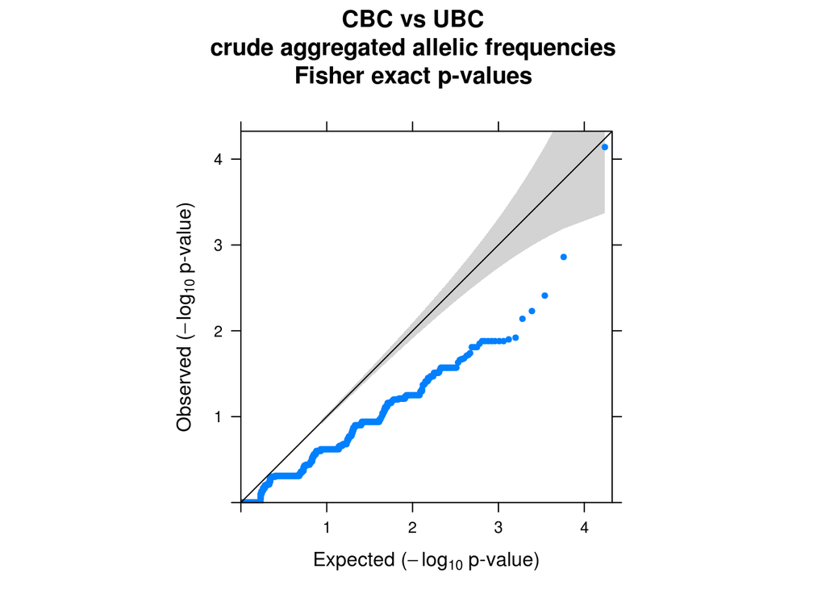

```r
# QQ-plot
qqunif.plot(genes_inv_aggr_info.df$cbc_ubc_fisher_p,
            main="CBC vs UBC\ncrude aggregated allelic frequencies\nFisher exact p-values")
```

```r
# Top 10 genes
x <- genes_inv_aggr_info.df[,c("gene","aggr_af_ubc", "aggr_af_cbc", "cbc_ubc_call", "cbc_ubc_fisher_p")]
x <- x[order(x$cbc_ubc_fisher_p),]
x[x$cbc_ubc_fisher_p<0.05,c("aggr_af_ubc", "aggr_af_cbc", "cbc_ubc_call", "cbc_ubc_fisher_p")]
```

```
##          aggr_af_ubc aggr_af_cbc cbc_ubc_call cbc_ubc_fisher_p
## FAM171B  0.036734694 0.002145923   protective     7.190688e-05
## VWA8     0.048979592 0.105150215         risk     1.396357e-03
## EPX      0.040816327 0.010729614   protective     3.891515e-03
## ECM1     0.004081633 0.025751073         risk     5.875219e-03
## SLC5A4   0.055102041 0.021459227   protective     7.172475e-03
## NHSL1    0.042857143 0.015021459   protective     1.203713e-02
## SPINK1   0.024489796 0.004291845   protective     1.268916e-02
## EPHB2    0.000000000 0.012875536         risk     1.319352e-02
## SZT2     0.000000000 0.012875536         risk     1.319352e-02
## REV3L    0.000000000 0.012875536         risk     1.319352e-02
## RAPSN    0.000000000 0.012875536         risk     1.319352e-02
## TROAP    0.000000000 0.012875536         risk     1.319352e-02
## MDM1     0.000000000 0.012875536         risk     1.319352e-02
## CACNA1H  0.000000000 0.012875536         risk     1.319352e-02
## DNAH3    0.079591837 0.040772532   protective     1.425093e-02
## TRMT61B  0.014285714 0.000000000   protective     1.548828e-02
## SPATA33  0.014285714 0.000000000   protective     1.548828e-02
## EMR1     0.014285714 0.000000000   protective     1.548828e-02
## C8A      0.002040816 0.017167382         risk     1.822139e-02
## RNF135   0.004081633 0.021459227         risk     1.897016e-02
## DPP4     0.024489796 0.055793991         risk     1.929921e-02
## TSEN54   0.026530612 0.006437768   protective     2.085372e-02
## FCN3     0.018367347 0.002145923   protective     2.122796e-02
## DUSP22   0.018367347 0.002145923   protective     2.122796e-02
## SIGLEC6  0.022448980 0.004291845   protective     2.211159e-02
## CFB      0.048979592 0.021459227   protective     2.331086e-02
## CCDC27   0.000000000 0.010729614         risk     2.721700e-02
## DBI      0.000000000 0.010729614         risk     2.721700e-02
## IQCA1    0.000000000 0.010729614         risk     2.721700e-02
## GYG1     0.000000000 0.010729614         risk     2.721700e-02
## PPAT     0.000000000 0.010729614         risk     2.721700e-02
## DXO      0.000000000 0.010729614         risk     2.721700e-02
## ECM2     0.000000000 0.010729614         risk     2.721700e-02
## OR52K1   0.000000000 0.010729614         risk     2.721700e-02
## TMEM134  0.000000000 0.010729614         risk     2.721700e-02
## ASIC1    0.000000000 0.010729614         risk     2.721700e-02
## PLEKHG3  0.000000000 0.010729614         risk     2.721700e-02
## DUOX1    0.000000000 0.010729614         risk     2.721700e-02
## SLC28A2  0.000000000 0.010729614         risk     2.721700e-02
```

[output cut: 13 more lines]

```
## ERCC6    0.002040816 0.015021459         risk     3.410981e-02
## SLC9A3R1 0.002040816 0.015021459         risk     3.410981e-02
## NOC3L    0.010204082 0.030042918         risk     3.568537e-02
## CALML4   0.010204082 0.030042918         risk     3.568537e-02
## CHEK2    0.010204082 0.030042918         risk     3.568537e-02
## POMGNT1  0.020408163 0.004291845   protective     3.810426e-02
## SLC26A4  0.016326531 0.002145923   protective     3.871104e-02
## SECISBP2 0.016326531 0.002145923   protective     3.871104e-02
## TLL2     0.016326531 0.002145923   protective     3.871104e-02
## SYTL4    0.016326531 0.002145923   protective     3.871104e-02
## IK       0.042857143 0.019313305   protective     4.148978e-02
## ACSF3    0.008163265 0.025751073         risk     4.281305e-02
## IGSF5    0.008163265 0.025751073         risk     4.281305e-02
## GPR133   0.020408163 0.045064378         risk     4.305342e-02
## MBOAT1   0.026530612 0.008583691   protective     4.825488e-02
```

```r
x[x$gene %in% c("ATM","CHEK2"),c("aggr_af_ubc", "aggr_af_cbc", "cbc_ubc_call", "cbc_ubc_fisher_p")]
```

```
##       aggr_af_ubc aggr_af_cbc cbc_ubc_call cbc_ubc_fisher_p
## CHEK2  0.01020408  0.03004292         risk       0.03568537
## ATM    0.01224490  0.01931330         risk       0.44149664
```

```r
# Clean-up
rm(header, gene, genes,
   cbc_cases, ubc_cases,
   cbc_fam_cases, cbc_nofam_cases,
   ubc_fam_cases, ubc_nofam_cases,
   x, genes_inv_aggr_info.mx, qqunif.plot)
```

## explore_inv_aggr_alt_counts_per_gene

```r
# Get alt alleles counts
inv_aggr_ac <- genes_inv_aggr_info.df$aggr_ac
names(inv_aggr_ac) <- rownames(genes_inv_aggr_info.df)

# Genes with highest counts of rare protein-affecting alt-alleles
x <- inv_aggr_ac[order(-inv_aggr_ac)]
mean(x) # ~5.4
```

```
## [1] 5.449069
```

```r
median(x) # 2
```

```
## [1] 2
```

```r
x[1:200]
```

```
##       DCHS2     PKHD1L1       MKI67     DENND4B        TPMT     ATP13A5
##          89          89          89          88          85          84
##     EFCAB13       MUC3A        VWA7      ZNF273       KRT77      NUDT17
##          84          82          81          81          79          74
##       OR6J1    SERPINA1        THEG      GPR113        VWA8       DNAH7
##          74          74          74          73          73          72
##       UTP20       OR4D6    C10ORF68        TLR2        MSR1         GIF
##          71          70          69          64          62          62
##        MDP1    SIGLEC12      COL6A6       ABCC1       TTLL6        CUBN
##          62          62          61          61          61          60
##     ELSPBP1        HELB         PAM       CD109       DNAH3    RPGRIP1L
##          60          59          58          58          58          58
##     PLA2G4C      FAM71D        TPTE        POLQ        LRBA       LRRC9
##          58          57          57          56          56          56
##         MPO     TMPRSS7         ZAN      OR10V1     ABHD12B        NOD2
##          56          55          55          55          55          55
##        APLF         LPA      CHRNA3      ATP10B      TCIRG1        ALG6
##          54          54          52          51          51          50
##       ABCB8      CCDC87        DSG3      LEPRE1     SLC12A8       ACSM4
##          49          49          49          48          48          48
##    KIAA0556        TCN2    KIAA1614      FAM81B     CYP3A43      CYB5R2
##          48          48          47          47          47          47
##       ZNF77      ZNF429         OTC      OR10G3        AVEN        AGRP
##          47          47          47          46          46          46
##       OR7G3        CBLC      SYNGR4      VWA5B1    KIAA1009      CCNYL2
##          46          46          46          45          45          45
##    SLC22A10       ALPK2       MEGF6      CNKSR1       CASP8       ERAP2
##          45          45          44          44          44          44
##       LAMB4     PLA2G4E        SYNC        GJB4       RRP15        MUC4
##          44          44          43          43          43          43
##      MROH2B      ZNF474      FBXL13        FGL1     FAM166B       OR4D9
##          43          43          43          43          43          43
##       ACADS      ZNF778       GNGT2        TMC8    HSD17B14       PRODH
##          43          43          43          43          43          43
##       SGIP1       WDR64        EXO1       LTBP1      PDE11A       MUC20
##          42          42          42          42          42          42
##          C2     C7orf31     CCDC136       HIP1R       SEPT1      CCDC68
##          42          42          42          42          42          42
##        OTOR    IGLV2-11       CCNL2       TRPM8     TMEM156     EPB41L2
##          42          42          41          41          41          41
```

[output cut: 13 more lines]

```
##          38          38          38          38          38          38
## CTA-992D9.6       ANXA9     C1orf27         BTD       HSPA4     SLC22A1
##          38          37          37          37          37          37
##       CCAR1       FOXM1     BCL2L14      SCAF11       PDIA2      EFCAB5
##          37          37          37          37          37          37
##      MVB12A      ZNF101      SLC5A4      PRSS38       DTHD1      UGT2A1
##          37          37          37          36          36          36
##       ADCY2    C6orf229       PRIM2     C7orf33     ANKRD16       OR5B3
##          36          36          36          36          36          36
##       ABCC6       ENDOV     TUBGCP6    C1orf194       FCRLB     CCDC141
##          36          36          36          35          35          35
##       WDR52       LRIT3     PCDHGB1       CDHR2    HLA-DPB1       PPIL1
##          35          35          35          35          35          35
##       NPSR1      SAMD9L
##          35          35
```

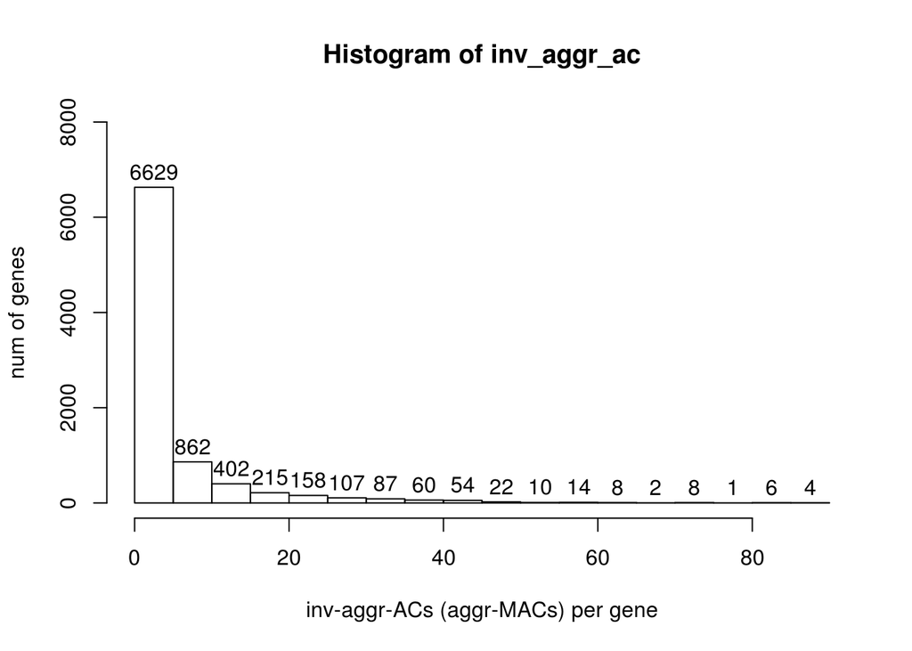

```r
# Histograms of aggregated MACs
hist(inv_aggr_ac, labels = TRUE, ylim=c(0,8000),
     xlab="inv-aggr-ACs (aggr-MACs) per gene", ylab="num of genes")
```

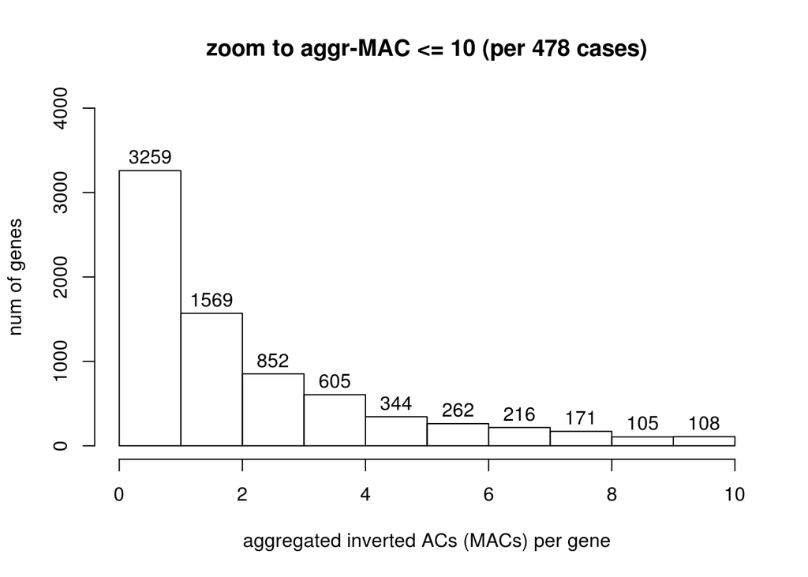

```r
hist(inv_aggr_ac[inv_aggr_ac<=10], breaks=c(0:10),
     labels = TRUE, ylim=c(0,4000), main="zoom to aggr-MAC <= 10 (per 478 cases)",
     xlab="aggregated inverted ACs (MACs) per gene", ylab="num of genes")
```

```r
# Counts < 10 (< 1% aggregated MAF) - too rare for analysis ??
sum(inv_aggr_ac < 10) # 7,383
```

```
## [1] 7383
```

```r
# Genes that may be analysed
sum(inv_aggr_ac >= 10) # 1,266 (ATM=15; CHEK2=19)
```

```
## [1] 1266
```

```r
# Aggregated MACs > 50 (~ >5% aggregated MAF)
sum(inv_aggr_ac > 50) # 53
```

```
## [1] 53
```

```r
# Clean-up
rm(inv_aggr_ac, x)
```

# data_summary

```r
dim(genotypes.mx)
```

```
## [1] 16809   478
```

```r
class(genotypes.mx)
```

```
## [1] "matrix"
```

```r
genotypes.mx[1:5,1:5]
```

```
##              P1_A01 P1_A02 P1_A03 P1_A04 P1_A05
## Var000000026      0     NA      0      0      0
## Var000000029      0      0      0      0      0
## Var000000031      0      0      0      0      0
## Var000000053      0      0      0      0     NA
## Var000000064      0      0      0      0     NA
```

```r
dim(kgen.df)
```

```
## [1] 16809     9
```

```r
colnames(kgen.df)
```

```
## [1] "SplitVarID"  "kgen.AC"     "kgen.AN"     "kgen.AF"     "kgen.AFR_AF"
## [6] "kgen.AMR_AF" "kgen.EAS_AF" "kgen.EUR_AF" "kgen.SAS_AF"
```

```r
kgen.df[1:5,1:5]
```

```
##                SplitVarID kgen.AC kgen.AN     kgen.AF kgen.AFR_AF
## Var000000026 Var000000026      NA      NA          NA          NA
## Var000000029 Var000000029       1    5008 0.000199681           0
## Var000000031 Var000000031       1    5008 0.000199681           0
## Var000000053 Var000000053      NA      NA          NA          NA
## Var000000064 Var000000064      NA      NA          NA          NA
```

```r
dim(exac.df)
```

```
## [1] 16809    48
```

```r
colnames(exac.df)
```

```
##  [1] "SplitVarID"              "exac_non_TCGA.AF"
##  [3] "exac_non_TCGA.AC"        "exac_non_TCGA.AN"
##  [5] "exac_non_TCGA.AC_FEMALE" "exac_non_TCGA.AN_FEMALE"
##  [7] "exac_non_TCGA.AC_MALE"   "exac_non_TCGA.AN_MALE"
##  [9] "exac_non_TCGA.AC_Adj"    "exac_non_TCGA.AN_Adj"
## [11] "exac_non_TCGA.AC_Hom"    "exac_non_TCGA.AC_Het"
## [13] "exac_non_TCGA.AC_Hemi"   "exac_non_TCGA.AC_AFR"
## [15] "exac_non_TCGA.AN_AFR"    "exac_non_TCGA.Hom_AFR"
## [17] "exac_non_TCGA.Het_AFR"   "exac_non_TCGA.Hemi_AFR"
## [19] "exac_non_TCGA.AC_AMR"    "exac_non_TCGA.AN_AMR"
## [21] "exac_non_TCGA.Hom_AMR"   "exac_non_TCGA.Het_AMR"
## [23] "exac_non_TCGA.Hemi_AMR"  "exac_non_TCGA.AC_EAS"
## [25] "exac_non_TCGA.AN_EAS"    "exac_non_TCGA.Hom_EAS"
## [27] "exac_non_TCGA.Het_EAS"   "exac_non_TCGA.Hemi_EAS"
## [29] "exac_non_TCGA.AC_FIN"    "exac_non_TCGA.AN_FIN"
## [31] "exac_non_TCGA.Hom_FIN"   "exac_non_TCGA.Het_FIN"
## [33] "exac_non_TCGA.Hemi_FIN"  "exac_non_TCGA.AC_NFE"
## [35] "exac_non_TCGA.AN_NFE"    "exac_non_TCGA.Hom_NFE"
## [37] "exac_non_TCGA.Het_NFE"   "exac_non_TCGA.Hemi_NFE"
## [39] "exac_non_TCGA.AC_SAS"    "exac_non_TCGA.AN_SAS"
## [41] "exac_non_TCGA.Hom_SAS"   "exac_non_TCGA.Het_SAS"
## [43] "exac_non_TCGA.Hemi_SAS"  "exac_non_TCGA.AC_OTH"
## [45] "exac_non_TCGA.AN_OTH"    "exac_non_TCGA.Hom_OTH"
## [47] "exac_non_TCGA.Het_OTH"   "exac_non_TCGA.Hemi_OTH"
```

```r
exac.df[1:5,1:5]
```

```
##                SplitVarID exac_non_TCGA.AF exac_non_TCGA.AC
## Var000000026 Var000000026               NA               NA
## Var000000029 Var000000029        1.506e-04               16
## Var000000031 Var000000031        2.354e-04               25
## Var000000053 Var000000053        1.883e-05                2
## Var000000064 Var000000064        9.416e-06                1
##              exac_non_TCGA.AN exac_non_TCGA.AC_FEMALE
## Var000000026               NA                      NA
## Var000000029           106210                       8
## Var000000031           106210                       4
## Var000000053           106210                       0
## Var000000064           106206                       0
```

```r
dim(variants.df)
```

```
## [1] 16809    45
```

```r
str(variants.df)
```

```
## 'data.frame':    16809 obs. of  45 variables:
##  $ SplitVarID        : Factor w/ 343824 levels "Var000000001",..: 26 29 31 53 64 227 237 300 413 430 ...
##  $ SYMBOL            : Factor w/ 19862 levels "A1BG","A1CF",..: 11149 11149 11149 8665 8665 540 540 18233 3808 6597 ...
##  $ TYPE              : Factor w/ 2 levels "INDEL","SNP": 2 2 2 2 2 2 2 2 2 2 ...
##  $ CHROM             : Factor w/ 25 levels "1","10","11",..: 1 1 1 1 1 1 1 1 1 1 ...
##  $ POS               : int  881871 883883 883946 897287 897792 987173 989899 1132513 1249141 1262635 ...
##  $ REF               : Factor w/ 2142 levels "A","AAAAAAAAAAAAAAAAAAAAAAAG",..: 1044 1575 539 539 539 1575 539 539 1044 1575 ...
##  $ ALT               : Factor w/ 1297 levels "A","AAAAAAAAAAAAACT",..: 1 323 989 989 989 664 989 989 1 1 ...
##  $ ac_raw            : int  1 2 1 1 1 1 1 2 1 1 ...
##  $ af_raw            : num  0.000711 0.001555 0.000774 0.000711 0.000722 ...
##  $ an_raw            : int  1406 1286 1292 1406 1386 1420 1414 1320 1378 1380 ...
##  $ Consequence       : Factor w/ 78 levels "3_prime_UTR_variant",..: 66 28 28 28 66 28 28 28 28 28 ...
##  $ SIFT_call         : Factor w/ 4 levels "deleterious",..: NA 1 1 1 NA 1 1 1 1 1 ...
##  $ SIFT_score        : num  NA 0 0.01 0.04 NA 0 0.02 0.02 0 0 ...
##  $ PolyPhen_call     : Factor w/ 4 levels "benign","possibly_damaging",..: NA 3 3 3 NA 3 3 3 3 3 ...
```

[output cut: 31 more lines]

```r
variants.df[1:5,1:5]
```

```
##                SplitVarID SYMBOL TYPE CHROM    POS
## Var000000026 Var000000026  NOC2L  SNP     1 881871
## Var000000029 Var000000029  NOC2L  SNP     1 883883
## Var000000031 Var000000031  NOC2L  SNP     1 883946
## Var000000053 Var000000053 KLHL17  SNP     1 897287
## Var000000064 Var000000064 KLHL17  SNP     1 897792
```

```r
dim(phenotypes.df)
```

```
## [1] 478  36
```

```r
str(phenotypes.df)
```

```
## 'data.frame':    478 obs. of  36 variables:
##  $ wes_id        : chr  "P1_A01" "P1_A02" "P1_A03" "P1_A04" ...
##  $ gwas_id       : chr  "id203568" "id357807" "id325472" "id304354" ...
##  $ merged_id     : chr  "P1_A01_id203568" "P1_A02_id357807" "P1_A03_id325472" "P1_A04_id304354" ...
##  $ filter        : chr  "pass" "pass" "pass" "pass" ...
##  $ cc            : int  1 1 1 1 1 1 0 1 1 0 ...
##  $ setno         : int  203568 357807 325472 304354 222648 244843 276284 297810 250898 226974 ...
##  $ registry      : Factor w/ 5 levels "de","IA","IR",..: 3 4 2 2 5 4 2 4 4 2 ...
##  $ family_history: int  1 0 1 1 1 1 1 1 1 0 ...
##  $ age_dx        : int  49 35 32 33 44 28 28 38 35 36 ...
##  $ age_ref       : num  58 36 41 34 49 28 32 44 35 38 ...
##  $ rstime        : num  10.17 1.83 9.75 1.59 5.66 ...
##  $ eig1_gwas     : num  -0.00389 -0.00379 -0.01011 -0.01288 -0.01086 ...
##  $ eig2_gwas     : num  0.00266 0.00246 -0.0001 0.00595 0.01157 ...
##  $ eig3_gwas     : num  0.06803 0.05055 -0.00603 0.00747 0.00144 ...
```

[output cut: 22 more lines]

```r
phenotypes.df[1:5,1:5]
```

```
##        wes_id  gwas_id       merged_id filter cc
## P1_A01 P1_A01 id203568 P1_A01_id203568   pass  1
## P1_A02 P1_A02 id357807 P1_A02_id357807   pass  1
## P1_A03 P1_A03 id325472 P1_A03_id325472   pass  1
## P1_A04 P1_A04 id304354 P1_A04_id304354   pass  1
## P1_A05 P1_A05 id222648 P1_A05_id222648   pass  1
```

```r
dim(genotypes_inv.mx)
```

```
## [1] 16809   478
```

```r
class(genotypes_inv.mx)
```

```
## [1] "matrix"
```

```r
genotypes_inv.mx[1:5,1:5]
```

```
##              P1_A01 P1_A02 P1_A03 P1_A04 P1_A05
## Var000000026      0     NA      0      0      0
## Var000000029      0      0      0      0      0
## Var000000031      0      0      0      0      0
## Var000000053      0      0      0      0     NA
## Var000000064      0      0      0      0     NA
```

```r
dim(variants_inv.df)
```

```
## [1] 16809    67
```

```r
str(variants_inv.df)
```

```
## 'data.frame':    16809 obs. of  67 variables:
##  $ SplitVarID        : Factor w/ 343824 levels "Var000000001",..: 26 29 31 53 64 227 237 300 413 430 ...
##  $ SYMBOL            : Factor w/ 19862 levels "A1BG","A1CF",..: 11149 11149 11149 8665 8665 540 540 18233 3808 6597 ...
##  $ TYPE              : Factor w/ 2 levels "INDEL","SNP": 2 2 2 2 2 2 2 2 2 2 ...
##  $ CHROM             : Factor w/ 25 levels "1","10","11",..: 1 1 1 1 1 1 1 1 1 1 ...
##  $ POS               : int  881871 883883 883946 897287 897792 987173 989899 1132513 1249141 1262635 ...
##  $ REF               : Factor w/ 2142 levels "A","AAAAAAAAAAAAAAAAAAAAAAAG",..: 1044 1575 539 539 539 1575 539 539 1044 1575 ...
##  $ ALT               : Factor w/ 1297 levels "A","AAAAAAAAAAAAACT",..: 1 323 989 989 989 664 989 989 1 1 ...
##  $ ac_raw            : int  1 2 1 1 1 1 1 2 1 1 ...
##  $ af_raw            : num  0.000711 0.001555 0.000774 0.000711 0.000722 ...
##  $ an_raw            : int  1406 1286 1292 1406 1386 1420 1414 1320 1378 1380 ...
##  $ Consequence       : Factor w/ 78 levels "3_prime_UTR_variant",..: 66 28 28 28 66 28 28 28 28 28 ...
##  $ SIFT_call         : Factor w/ 4 levels "deleterious",..: NA 1 1 1 NA 1 1 1 1 1 ...
##  $ SIFT_score        : num  NA 0 0.01 0.04 NA 0 0.02 0.02 0 0 ...
##  $ PolyPhen_call     : Factor w/ 4 levels "benign","possibly_damaging",..: NA 3 3 3 NA 3 3 3 3 3 ...
```

[output cut: 53 more lines]

```r
variants_inv.df[1:5,1:5]
```

```
##                SplitVarID SYMBOL TYPE CHROM    POS
## Var000000026 Var000000026  NOC2L  SNP     1 881871
## Var000000029 Var000000029  NOC2L  SNP     1 883883
## Var000000031 Var000000031  NOC2L  SNP     1 883946
## Var000000053 Var000000053 KLHL17  SNP     1 897287
## Var000000064 Var000000064 KLHL17  SNP     1 897792
```

```r
dim(genes_inv_aggr_data.mx)
```

```
## [1] 8649  478
```

```r
class(genes_inv_aggr_data.mx)
```

```
## [1] "matrix"
```

```r
genes_inv_aggr_data.mx[1:5,1:5]
```

```
##        P1_A01 P1_A02 P1_A03 P1_A04 P1_A05
## NOC2L       0      0      0      0      0
## KLHL17      0      0      0      0      0
## AGRN        0      0      0      0      0
## TTLL10      0      0      0      0      0
## CPSF3L      0      0      0      0      0
```

```r
dim(genes_inv_aggr_info.df)
```

```
## [1] 8649   27
```

```r
str(genes_inv_aggr_info.df)
```

```
## 'data.frame':    8649 obs. of  27 variables:
##  $ gene             : chr  "NOC2L" "KLHL17" "AGRN" "TTLL10" ...
##  $ num_var          : num  3 2 2 1 1 1 1 2 1 1 ...
##  $ inverted         : logi  FALSE FALSE FALSE FALSE FALSE FALSE ...
##  $ multiallelic     : logi  FALSE FALSE FALSE FALSE FALSE FALSE ...
##  $ aggr_ac          : num  4 2 2 2 1 1 41 3 1 1 ...
##  $ aggr_an          : num  956 956 956 956 956 956 956 956 956 956 ...
##  $ aggr_af          : num  0.00418 0.00209 0.00209 0.00209 0.00105 ...
##  $ aggr_ac_cbc      : num  3 2 1 2 1 1 20 2 0 1 ...
##  $ aggr_an_cbc      : num  466 466 466 466 466 466 466 466 466 466 ...
##  $ aggr_af_cbc      : num  0.00644 0.00429 0.00215 0.00429 0.00215 ...
##  $ aggr_ac_ubc      : num  1 0 1 0 0 0 21 1 1 0 ...
##  $ aggr_an_ubc      : num  490 490 490 490 490 490 490 490 490 490 ...
##  $ aggr_af_ubc      : num  0.00204 0 0.00204 0 0 ...
##  $ aggr_ac_cbc_fam  : num  1 0 0 2 0 1 9 0 0 0 ...
##  $ aggr_an_cbc_fam  : num  166 166 166 166 166 166 166 166 166 166 ...
##  $ aggr_af_cbc_fam  : num  0.00602 0 0 0.01205 0 ...
##  $ aggr_ac_cbc_nofam: num  2 2 1 0 1 0 11 2 0 1 ...
##  $ aggr_an_cbc_nofam: num  300 300 300 300 300 300 300 300 300 300 ...
##  $ aggr_af_cbc_nofam: num  0.00667 0.00667 0.00333 0 0.00333 ...
##  $ aggr_ac_ubc_fam  : num  0 0 0 0 0 0 8 0 1 0 ...
##  $ aggr_an_ubc_fam  : num  142 142 142 142 142 142 142 142 142 142 ...
##  $ aggr_af_ubc_fam  : num  0 0 0 0 0 ...
##  $ aggr_ac_ubc_nofam: num  1 0 1 0 0 0 13 1 0 0 ...
##  $ aggr_an_ubc_nofam: num  348 348 348 348 348 348 348 348 348 348 ...
##  $ aggr_af_ubc_nofam: num  0.00287 0 0.00287 0 0 ...
##  $ cbc_ubc_call     : Factor w/ 2 levels "protective","risk": 2 2 2 2 2 2 2 2 1 2 ...
##  $ cbc_ubc_fisher_p : num  0.362 0.237 1 0.237 0.487 ...
```

```r
genes_inv_aggr_info.df[1:5,1:5]
```

```
##          gene num_var inverted multiallelic aggr_ac
## NOC2L   NOC2L       3    FALSE        FALSE       4
## KLHL17 KLHL17       2    FALSE        FALSE       2
## AGRN     AGRN       2    FALSE        FALSE       2
## TTLL10 TTLL10       1    FALSE        FALSE       2
## CPSF3L CPSF3L       1    FALSE        FALSE       1
```

```r
# Check consistency of rownames and colnames
sum(colnames(genotypes.mx) != rownames(phenotypes.df))
```

```
## [1] 0
```

```r
sum(rownames(genotypes.mx) != rownames(kgen.df))
```

```
## [1] 0
```

```r
sum(rownames(genotypes.mx) != rownames(exac.df))
```

```
## [1] 0
```

```r
sum(rownames(genotypes.mx) != rownames(variants.df))
```

```
## [1] 0
```

```r
sum(colnames(genes_inv_aggr_data.mx) != rownames(phenotypes.df))
```

```
## [1] 0
```

```r
sum(rownames(genes_inv_aggr_info.df) != rownames(genes_inv_aggr_data.mx))
```

```
## [1] 0
```

# save_data

```r
#base_folder="/analysis/mtgroup_share/users/alexey/wecare_only_08.17"
save.image(paste(base_folder, "results", "r08_filter_by_inverted_af_wecare_only.RData", sep="/"))
```

# final_section

```r
ls()
```

```
##  [1] "base_folder"            "exac.df"
##  [3] "genes_inv_aggr_data.mx" "genes_inv_aggr_info.df"
##  [5] "genotypes_inv.mx"       "genotypes.mx"
##  [7] "kgen.df"                "phenotypes.df"
##  [9] "variants.df"            "variants_inv.df"
```

```r
Sys.time()
```

```
## [1] "2017-08-29 19:27:27 BST"
```